# Probabilidad y Estadística con Python

[output not shown]

[output cut: 51398 more lines]

```
Al paciente:  23241  se le asigna una CAMA   hospital  B
Al paciente:  23254  se le asigna una CAMA   hospital  B
Al paciente:  23260  se le asigna una CAMA   hospital  B
Al paciente:  23235  se le asigna una CAMA   hospital  A
Al paciente:  23236  se le asigna una CAMA   hospital  A
Al paciente:  23247  se le asigna una CAMA   hospital  A
Al paciente:  23252  se le asigna una CAMA   hospital  A
Al paciente:  23258  se le asigna una CAMA   hospital  A
Al paciente:  23264  se le asigna una CAMA   hospital  A
Al paciente:  23273  se le asigna una CAMA   hospital  A
###Resultados pacientes###
Recuperados:
{17: 6, 18: 8, 19: 20, 20: 31, 21: 31, 22: 51, 23: 47, 24: 26, 25: 40, 26: 47, 27: 49, 28: 22, 29: 30}
Fallecidos:
{1: 3814, 2: 3971, 3: 4009, 4: 445, 5: 421, 6: 403, 7: 407, 8: 444, 9: 437, 10: 434, 11: 408, 12: 424, 13: 439, 14: 435, 15: 438, 16: 439, 17: 456, 18: 445, 19: 372, 20: 364, 21: 419, 22: 418, 23: 408, 24: 374, 25: 447, 26: 363, 27: 383, 28: 380, 29: 384}
```

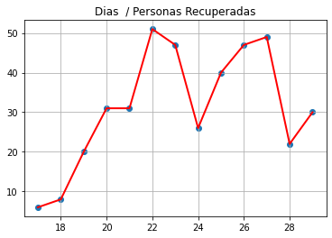

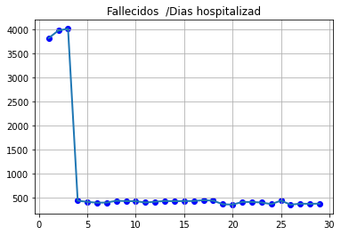

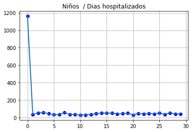

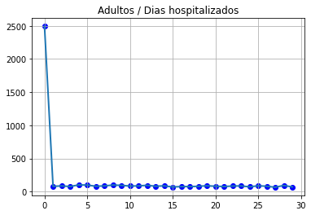

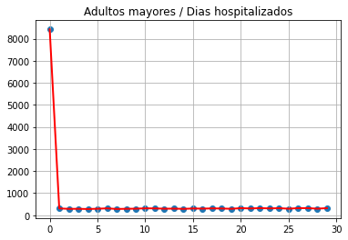

```python
                    else:
                        print("El paciente " , paciente, " en el hospital ", hospital.name, " espero ", wait_fpersonal , " dias y fallece ya no hay personal requerido")
                        persona_fallecidas[env.now] = persona_fallecidas[env.now] + 1 if env.now in persona_fallecidas else  1

            else:
                print("El paciente " , paciente, " en el hospital ", hospital.name, " espero ", wait , " dias y fallece no hay camas")
                persona_fallecidas[env.now] = persona_fallecidas[env.now] + 1 if env.now in persona_fallecidas else  1





    if (estado <= 100 and estado >= 31):
        a_mayor[env.now] = a_mayor[env.now] + 1 if env.now in a_mayor else  1

        with hospital.camas.request() as cama:
            dias_esperando = random.randint(1,3) #Numero de dias maximo que puede esperar sin ser asignado a una cama dentro del hospital
            requerimiento = yield cama | env.timeout(dias_esperando) #Asignar un tiempo de espera
            wait = env.now - arrive
            if cama in requerimiento:
                print("Al paciente: ", paciente, " se le asigna una CAMA ", " hospital " , hospital.name)
                yield env.process(hospital.ingresar_paciente(paciente))
                arrive2 = env.now
                camas_atendidos.append(1)
                with hospital.personal.request() as persona:
                    dias_esperando_personal = random.randint(1,2)
                    requerimiento2 = yield persona | env.timeout(dias_esperando_personal)
                    wait_fpersonal = env.now - arrive2
                    if persona in requerimiento2:
                        print("Al paciente: ", paciente, " recibe atencion del personal ", " hospital " , hospital.name)
                        yield env.process(hospital.uso_personal_paciente(paciente))
                        arrive3 = env.now
                        personal_atiende.append(1)
                        with hospital.equipos.request() as equipo:
                            dias_esperando_equipo = random.randint(1,2)
                            requerimiento3 = yield equipo | env.timeout(dias_esperando_equipo)
                            wait_fequipo = env.now - arrive3
                            if equipo in requerimiento3:
                                print("Al paciente: ", paciente, " recibe equipos ", " hospital " , hospital.name)
                                yield env.process(hospital.uso_equipo_paciente(paciente))
                                estado = random.randint(1,100)
                                atendidos_equip.append(1)
                                if (estado < 8) :
                                    persona_fallecidas[env.now] = persona_fallecidas[env.now] + 1 if env.now in persona_fallecidas else  1
                                else:
                                    persona_recuperadas[env.now] = persona_recuperadas[env.now] + 1 if env.now in persona_recuperadas else 1
                            else:
                                print("El paciente " , paciente, " en el hospital ", hospital.name, " espero ", wait_fequipo , " dias y fallece no hubo el equipo disponible")
                                persona_fallecidas[env.now] = persona_fallecidas[env.now] + 1 if env.now in persona_fallecidas else  1

                    else:
                        print("El paciente " , paciente, " en el hospital ", hospital.name, " espero ", wait_fpersonal , " dias y fallece ya que no hay personal")
                        persona_fallecidas[env.now] = persona_fallecidas[env.now] + 1 if env.now in persona_fallecidas else  1

            else:
                print("El paciente " , paciente, " en el hospital ", hospital.name, " espero ", wait , " dias y fallece porque no hay camas suficientes")
                persona_fallecidas[env.now] = persona_fallecidas[env.now] + 1 if env.now in persona_fallecidas else  1



def ejecutar(env, tasa_crecimiento, infectados):
    hospitalA = Hospital(env, HOSPITAL_CAMA_A,HOSPITAL_Personal_A,HOSPITAL_Equipos_A, "A")
    hospitalB = Hospital(env, HOSPITAL_CAMA_B,HOSPITAL_Personal_B,HOSPITAL_Equipos_B, "B")
    for i in range(infectados):
        asignar_hospital(env, hospitalA, hospitalB, i)
    paciente = infectados
    while True:
        yield env.timeout(1)
        for i in range(tasa_crecimiento):
            paciente += 1
            asignar_hospital(env, hospitalA, hospitalB, paciente)

def asignar_hospital(env, hospitalA, hospitalB, paciente):
    hosp_esc = random.randint(1,2)
    if (hosp_esc == 1):
        print("Llega paciente nuevo : ", paciente, " hospital A tiempo ", env.now)
        env.process(llegada_paciente(env, hospitalA, paciente))
    else:
        print("Llega paciente nuevo : ", paciente, " hospital B tiempo ", env.now)
        env.process(llegada_paciente(env, hospitalB, paciente))

print("Simulacion COVID 19")
env=simpy.Environment()
env.process(ejecutar(env,TASA_CRECIMIENTO, INFECTADOS))
env.run(until=DIAS_SIMULACION)

print("###Resultados pacientes###")
print("Recuperados: ")
print(persona_recuperadas)
print("Fallecidos: ")
print(persona_fallecidas)

datos=sorted(persona_recuperadas.items()) # Ordenamos los datos
x, y =zip(*datos) # Obtener x(tiempo - clave) y el y(Numero de pacientes atendidos - valor)
pp.plot(x,y,linewidth=2,color='red') # Dibujamos las lineas
pp.scatter(x,y) # Dibujamos los puntos (x,y)
pp.title("Dias  / Personas Recuperadas")
pp.grid(True) # Generamos una cuadricula
pp.show() # Mostramos el grafico

if (persona_fallecidas):
    datos=sorted(persona_fallecidas.items()) # Ordenamos los datos
    x, y =zip(*datos) # Obtener x(tiempo - clave) y el y(Numero de pacientes atendidos - valor)
    pp.plot(x,y,linewidth=2) #Dibujamos las lineas
    pp.scatter(x,y,color='blue') # Dibujamos los puntos (x,y)
    pp.title("Fallecidos  /Dias hospitalizad")
    pp.grid(True) #Generamos una cuadricula
    pp.show() #Mostramos el grafico
if (ninos):
    datos=sorted(ninos.items()) # Ordenamos los datos
    x, y =zip(*datos) # Obtener x(tiempo - clave) y el y(Numero de pacientes atendidos - valor)
    pp.plot(x,y,linewidth=2) #Dibujamos las lineas
    pp.scatter(x,y,color='blue') # Dibujamos los puntos (x,y)
    pp.title("Niños  / Dias hospitalizados")
    pp.grid(True) #Generamos una cuadricula
    pp.show() #Mostramos el grafico
if (adultos):
    datos=sorted(adultos.items()) # Ordenamos los datos
    x, y =zip(*datos) # Obtener x(tiempo - clave) y el y(Numero de pacientes atendidos - valor)
    pp.plot(x,y,linewidth=2) #Dibujamos las lineas
    pp.scatter(x,y,color='blue') # Dibujamos los puntos (x,y)
    pp.title("Adultos / Dias hospitalizados")
    pp.grid(True) #Generamos una cuadricula
    pp.show() #Mostramos el grafico
if (a_mayor):
    datos=sorted(a_mayor.items()) # Ordenamos los datos
    x, y =zip(*datos) # Obtener x(tiempo - clave) y el y(Numero de pacientes atendidos - valor)
    pp.plot(x,y,linewidth=2,color='red') #Dibujamos las lineas
    pp.scatter(x,y) # Dibujamos los puntos (x,y)
    pp.title("Adultos mayores / Dias hospitalizados")
    pp.grid(True) #Generamos una cuadricula
    pp.show() #Mostramos el grafico
```

## Calculo de COSTOS

```python
costo1=(sum(pacientes_atendidos_camas)*(costo_persona-1200))
costo2=(sum(pacientes_atendidos_personal)*(costo_persona-2000))
costo3=(sum(pacientes_atendidos_equipos)*(costo_persona))
print("El Total en costo en 20 dias en la Provincia del Guayas son: ",(costo1+costo2+costo3))
```

[output not shown]

## Conclusiones

> > Como se puede apreciar la libreria simpy es muy util a la hora de hacer simulacion de eventos discretos, en este caso nos ayudo a conocer el estado de la utilizacion de los recursos en la provincia del Guayas, especificamente en 2 hosspitales que se encuentran en la capital de dicha provincia.

## Recomendaciones

> > Usar los datos actualizados, para obtener mayor precision en los resultados.

## Opiniones

> > La provincia del Guayas ha sido una de las mas afectadas respecto al tema del Covid19, debido a que se tuvo un sistema de Salud deficiente para atender una pandemia como esta, es por eso que el sistema de salud colapso principalmente en la ciudad de Guayaquil.